# Exploratory Data Analysis

Kailen Shantz

Last updated: 2019-02-26

In this notebook, I’ll be exploring the data that has been scraped from the web and cleaned to get a sense of what features might do well at predicting a season’s winner, how the data should be modeled, and what types of feature transforms might be useful.

```r
# load libraries
library(here)
library(tidyverse)
library(forcats)
library(ggbeeswarm)

# load data
rpdr <- readr::read_delim(here("data/processed/rpdr_df.txt"), delim = "\t")
```

To start, we’ll take a look at the structure of the data and some summary statistics.

```r
str(rpdr)
```

```
Classes ‘tbl_df’, ‘tbl’ and 'data.frame':   129 obs. of  15 variables:
 $ season             : num  1 1 1 1 1 1 1 1 1 2 ...
 $ contestant         : chr  "Akashia" "BeBe Zahara Benet" "Jade" "Nina Flowers" ...
 $ name               : chr  "Eric Flint" "Nea Marshall Kudi Ngwa" "David Sotomayor" "Jorge Luis Flores Sanchez" ...
 $ age                : num  24 28 25 34 26 26 29 29 39 29 ...
 $ hometown           : chr  "Cleveland, Ohio" "Minneapolis, Minnesota" "Chicago, Illinois" "Bayamón, Puerto Rico" ...
 $ was_winner         : logi  FALSE TRUE FALSE FALSE FALSE FALSE ...
 $ n_episodes         : num  6 6 6 6 6 6 6 6 6 9 ...
 $ n_contestants      : num  9 9 9 9 9 9 9 9 9 12 ...
 $ n_appearances      : num  3 6 4 6 5 6 6 2 1 7 ...
 $ n_lipsync          : num  3 1 1 0 1 2 2 1 1 1 ...
 $ n_in_top           : num  0 3 0 5 4 2 2 0 0 4 ...
 $ n_in_bottom        : num  4 1 3 1 2 3 4 2 2 2 ...
 $ n_safe             : num  0 2 2 0 0 1 1 1 0 2 ...
 $ n_wins             : num  0 2 0 1 2 1 0 0 0 1 ...
 $ mini_challenge_wins: num  1 0 1 1 1 1 0 0 0 0 ...
 - attr(*, "spec")=
  .. cols(
  ..   season = col_double(),
  ..   contestant = col_character(),
  ..   name = col_character(),
  ..   age = col_double(),
  ..   hometown = col_character(),
  ..   was_winner = col_logical(),
  ..   n_episodes = col_double(),
  ..   n_contestants = col_double(),
  ..   n_appearances = col_double(),
  ..   n_lipsync = col_double(),
  ..   n_in_top = col_double(),
  ..   n_in_bottom = col_double(),
  ..   n_safe = col_double(),
  ..   n_wins = col_double(),
  ..   mini_challenge_wins = col_double()
  .. )
```

Unsurprisingly, `season` has been read in as a numeric variable. This shouldn’t matter, but just to be safe let’s change this to a factor. Note that I’m choosing a factor instead of a character vector so that the order of seasons will be preserved.

```r
rpdr$season <- forcats::as_factor(as.character(rpdr$season))
```

```r
summary(rpdr)
```

```
     season    contestant            name                age          hometown         was_winner
 10     :14   Length:129         Length:129         Min.   :21.00   Length:129         Mode :logical
 5      :14   Class :character   Class :character   1st Qu.:25.00   Class :character   FALSE:119
 6      :14   Mode  :character   Mode  :character   Median :28.00   Mode  :character   TRUE :10
 7      :14                                         Mean   :28.95
 9      :14                                         3rd Qu.:32.00
 3      :13                                         Max.   :52.00
 (Other):46
   n_episodes    n_contestants   n_appearances      n_lipsync        n_in_top      n_in_bottom
 Min.   : 6.00   Min.   : 9.00   Min.   : 1.000   Min.   :0.000   Min.   :0.000   Min.   :0.000
 1st Qu.: 9.00   1st Qu.:12.00   1st Qu.: 4.000   1st Qu.:1.000   1st Qu.:0.000   1st Qu.:1.000
 Median :12.00   Median :14.00   Median : 7.000   Median :1.000   Median :2.000   Median :2.000
 Mean   :11.02   Mean   :13.08   Mean   : 6.938   Mean   :1.574   Mean   :2.341   Mean   :2.271
 3rd Qu.:12.00   3rd Qu.:14.00   3rd Qu.:10.000   3rd Qu.:2.000   3rd Qu.:4.000   3rd Qu.:3.000
 Max.   :12.00   Max.   :14.00   Max.   :12.000   Max.   :4.000   Max.   :8.000   Max.   :7.000

     n_safe          n_wins       mini_challenge_wins
 Min.   :0.000   Min.   :0.0000   Min.   :0.0000
 1st Qu.:1.000   1st Qu.:0.0000   1st Qu.:0.0000
 Median :2.000   Median :0.0000   Median :0.0000
 Mean   :2.264   Mean   :0.8605   Mean   :0.6822
 3rd Qu.:4.000   3rd Qu.:2.0000   3rd Qu.:1.0000
 Max.   :6.000   Max.   :4.0000   Max.   :5.0000
```

Overall, these look like reasonable values, suggesting that nothing has gone wrong in the data processing steps. It is notable that the max values for being in the top, in the bottom and winning the mini challenges are rather high compared to the means. So let’s take a closer look at these.

```r
rpdr$contestant[(rpdr$n_in_top == 8)]
```

```
[1] "Jinkx Monsoon"
```

```r
rpdr$contestant[(rpdr$n_in_bottom == 7)]
```

```
[1] "Darienne Lake"
```

```r
rpdr$contestant[(rpdr$mini_challenge_wins == 5)]
```

```
[1] "Detox"
```

Looking at the Wikipedia pages for each contestant’s season, it appears that these data are, in fact correct.

# Exploring the raw data

Next, let’s get a sense of how the data for each performance metric is distributed, and where the winners tend to fall.

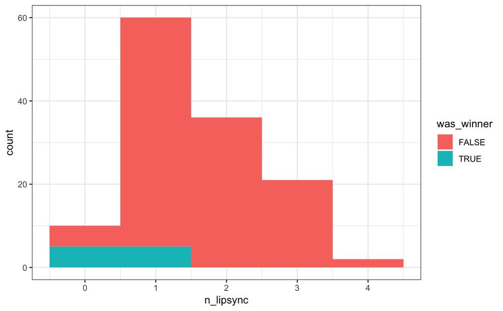

```r
ggplot(rpdr, aes(x = n_lipsync, fill = was_winner)) +
  geom_histogram(binwidth = 1) +
  theme_bw()
```

Unsurprisingly, the season winners tended to have fewer lipsyncs, and half of the time, the winner never had to lipsync. No winner has ever had to lipsync more than once. So this is likely a helpful predictor. But it’s also far from sufficient, given how many non-winners either never had to lipsync, or only had one lipsync.

This also doesn’t capture the fact that some people who had to lipsync once also went home that very episode. A more useful way to look at this data might be to examine times in the bottom vs number of lipsyncs. (later)

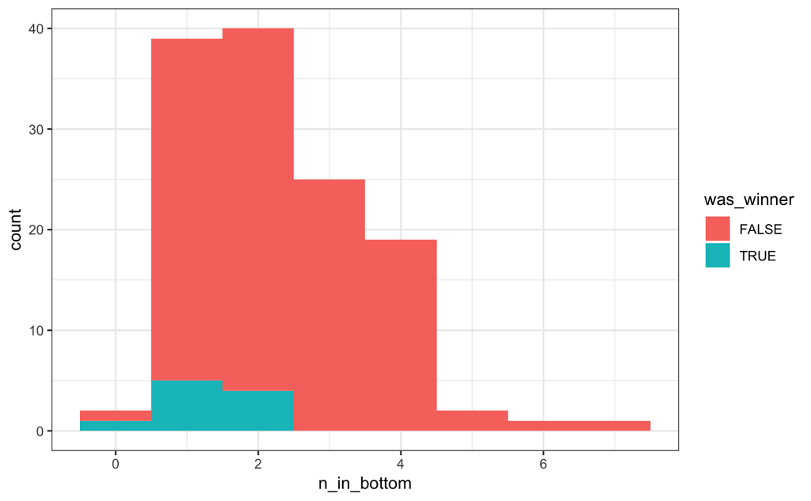

```r
ggplot(rpdr, aes(x = n_in_bottom, fill = was_winner)) +
  geom_histogram(binwidth = 1) +
  theme_bw()
```

Again, no surprises here. The winners tended to be in the bottom few times. But again, we can also see that this is far from a perfect predictor of the winner.

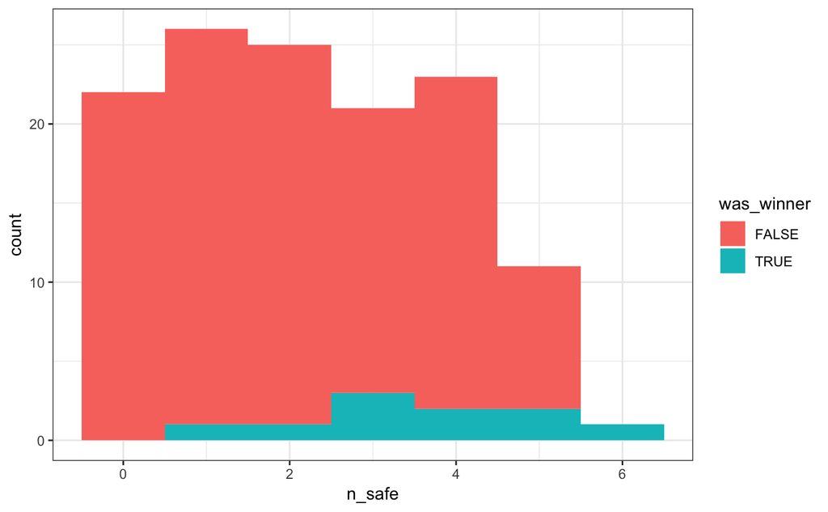

```r
ggplot(rpdr, aes(x = n_safe, fill = was_winner)) +
  geom_histogram(binwidth = 1) +
  theme_bw()
```

This looks like a less informative predictor. The distribution appears to be relatively uniform. The winners are spread across all possible values for the number of time safe except 0. So minimnally, we can say that all winners have been safe at least once.

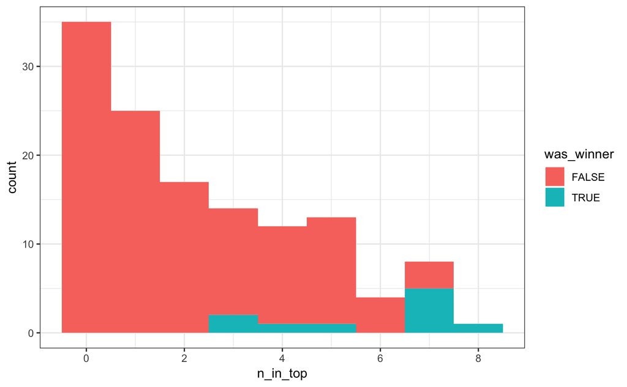

```r
ggplot(rpdr, aes(x = n_in_top, fill = was_winner)) +
  geom_histogram(binwidth = 1) +
  theme_bw() +
  scale_x_continuous(breaks = c(0, 2, 4, 6, 8))
```

Nothing here should be particularly surprising. Season winners tended to be in the top a fair number of times, and have thus far never been in the top fewer than 3 times.

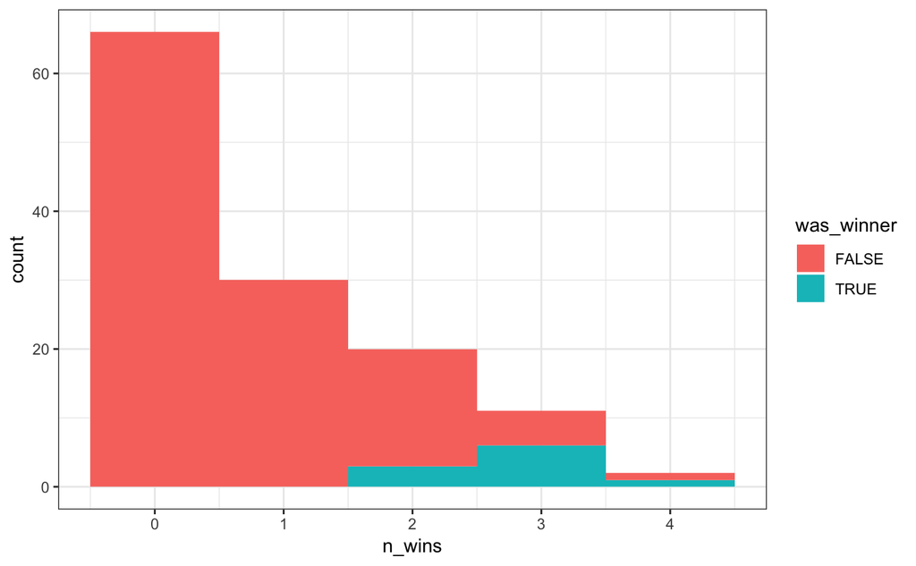

```r
ggplot(rpdr, aes(x = n_wins, fill = was_winner)) +
  geom_histogram(binwidth = 1) +
  theme_bw()
```

Just like we saw for times in the top, season winners fall on the right tail of this distribution, always having multiple wins.

It’s worth considering that using count data might be a little misleading. On the one hand, the winners tend to cluster together in the histograms, but we did observe some separation for the winners when it came to how often they were in the top. One potential problem is that there are a different number of episodes and different numbers of competitors across seasons. And using pure count data doesn’t take that variation into account. So for starters, let’s take a look at how these distributions vary across seasons.

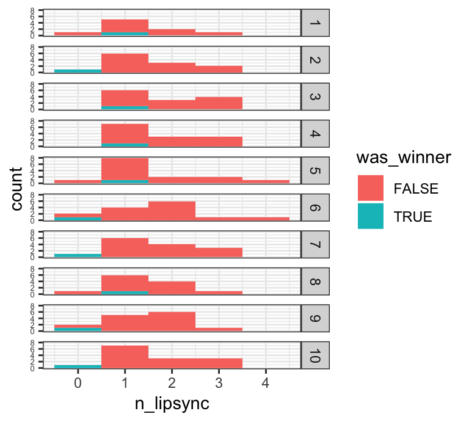

These distributions actually look quite comparable across seasons. We can see, now, that the winner was not always the person with the fewest lipsyncs. But, again, this is a limitation of using count data. It doesn’t capture facts like how a contestant can lipsync once and then be sent home that same episode.

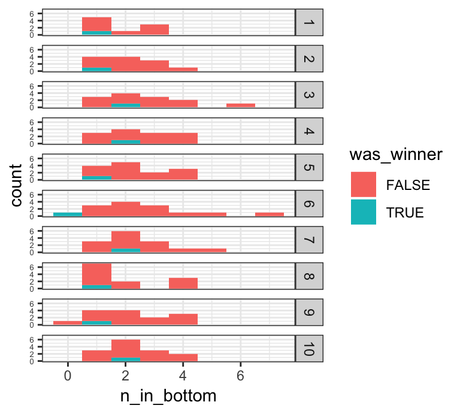

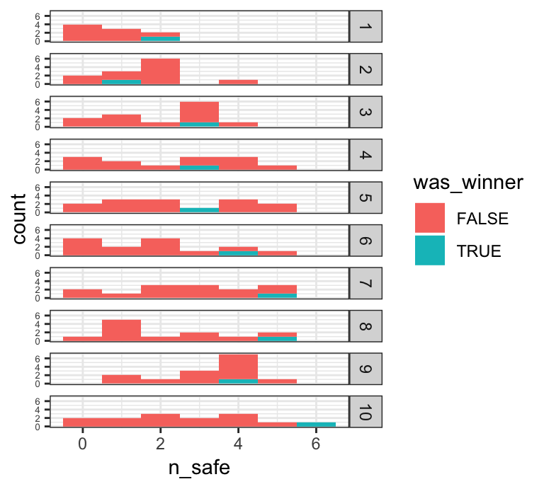

```r
ggplot(rpdr, aes(x = n_safe, fill = was_winner)) +
  geom_histogram(binwidth = 1) +
  facet_grid(season~.) +
  theme_bw() +
  theme(axis.text.y = element_text(size = 5))
```

For the most part, these data look consistent with what we saw in the aggregated data: there is a relitively uniform distribution in each seasons. One thing that does stand out is that as we go from earlier to later seasons, the number of times the winner is safe has increased.

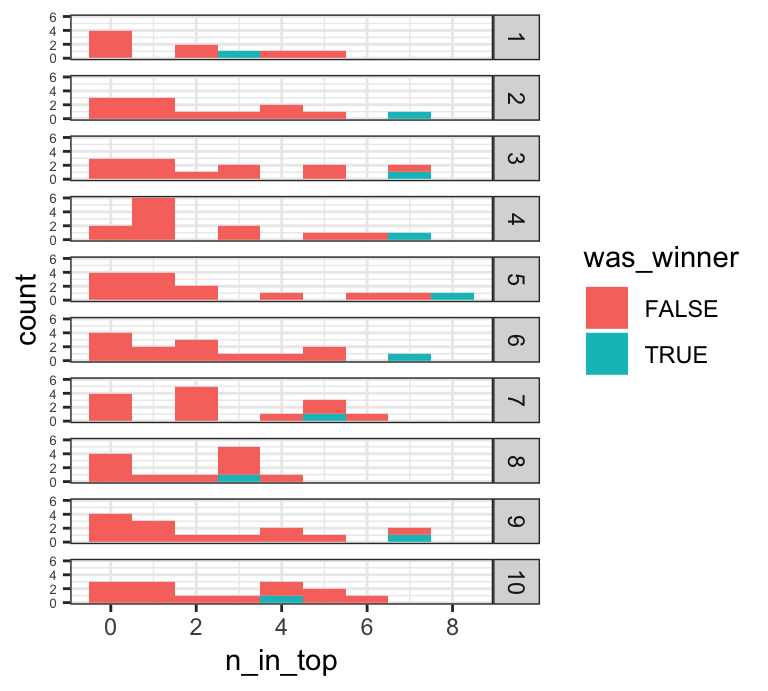

```r
ggplot(rpdr, aes(x = n_in_top, fill = was_winner)) +
  geom_histogram(binwidth = 1) +
  facet_grid(season~.) +
  theme_bw() +
  theme(axis.text.y = element_text(size = 5)) +
  scale_x_continuous(breaks = c(0, 2, 4, 6, 8))
```

Here we can see that while there is variation across seasons, for the most part, the winner tends to be consistently in the top.

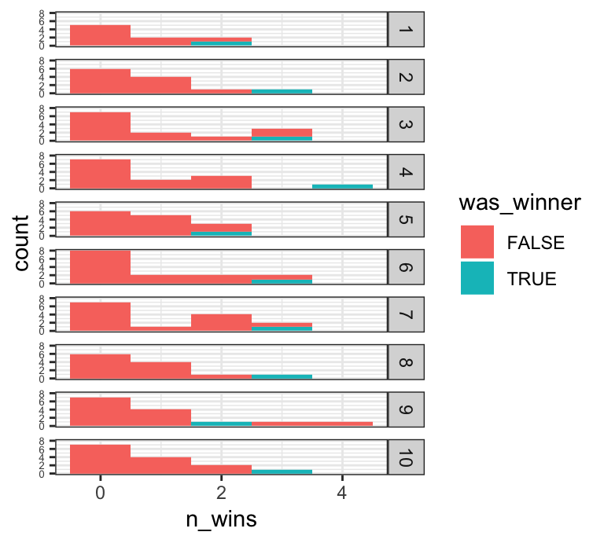

```r
ggplot(rpdr, aes(x = n_wins, fill = was_winner)) +
  geom_histogram(binwidth = 1) +
  facet_grid(season~.) +
  theme_bw() +
  theme(axis.text.y = element_text(size = 5)) +
  scale_x_continuous(breaks = c(0, 2, 4, 6, 8))
```

These plot reveals more to us than the aggregate plot. Here we can very cleary see that, with the exception of season 9, the winner consistently has either the most wins, or is tied with one or two other contestants for the most wins.

Now that we’ve got a sense of what the data look like, let’s take a deeper look at each season to see how the competitors stack up against one another. To do this, I’ll be plotting stacked barcharts for how often each participant in a season lipsynced, was in the bottom, was safe, was in the top and won.

Note that times in the bottom includes the times that a participant had to lispync. So, for example the first person to get sent home would be in the bottom the same number of times that they lipsynced.

Similarly, times in the top includes wins. So if a participant was in the top the same number of times that they won, this means that they won every time they were in the top.

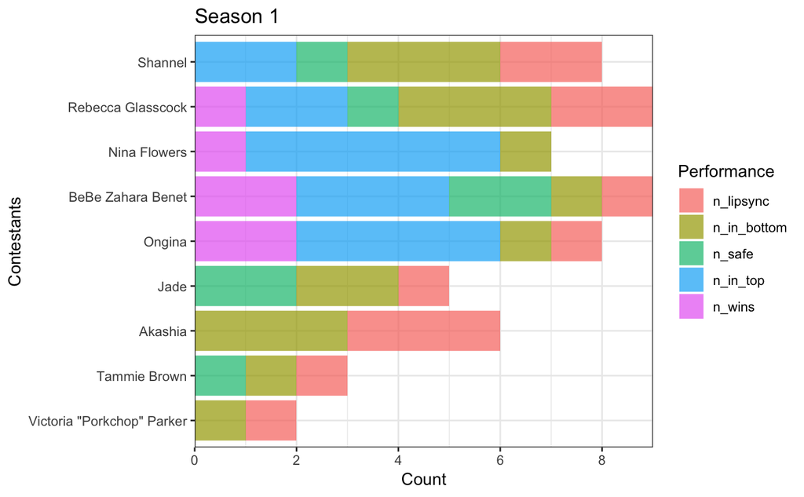

```r
rpdr %>% gather(key = "performance", value = "count", n_lipsync:n_wins) %>%
  filter(season == 1) %>%
  ggplot(aes(x = reorder(contestant, n_appearances), y = count, fill = fct_relevel(performance, "n_lipsync", "n_in_bottom", "n_safe", "n_in_top", "n_wins"))) +
  geom_col(alpha = 0.7) +
  coord_flip() +
  labs(y = "Count", fill  = "Performance", x = "Contestants", title = "Season 1") +
  theme_bw() + scale_y_continuous(breaks = c(0, 2, 4, 6, 8, 10, 12, 14, 16, 18), expand = c(0,0))
```

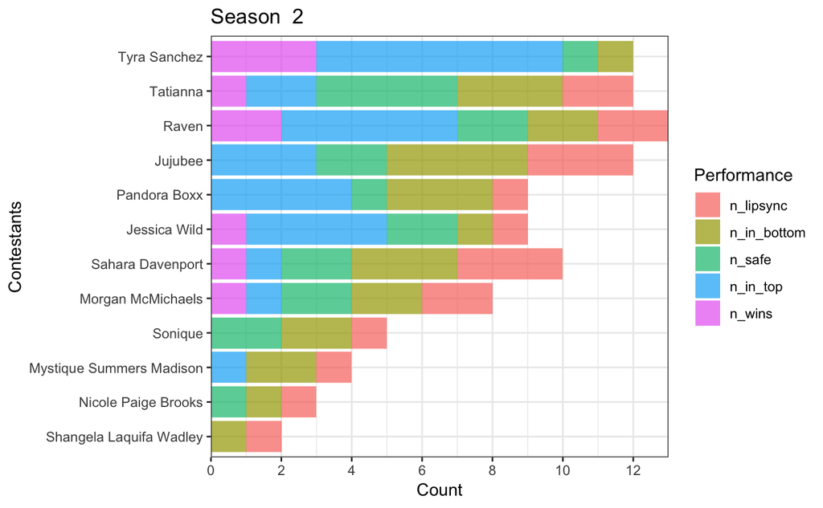

```r
rpdr %>% gather(key = "performance", value = "count", n_lipsync:n_wins) %>%
  filter(season == 2) %>%
  ggplot(aes(x = reorder(contestant, n_appearances), y = count, fill = fct_relevel(performance, "n_lipsync", "n_in_bottom", "n_safe", "n_in_top", "n_wins"))) +
  geom_col(alpha = 0.7) +
  coord_flip() +
  labs(y = "Count", fill  = "Performance", x = "Contestants", title = "Season  2") +
  theme_bw() + scale_y_continuous(breaks = c(0, 2, 4, 6, 8, 10, 12, 14, 16, 18), expand = c(0,0))
```

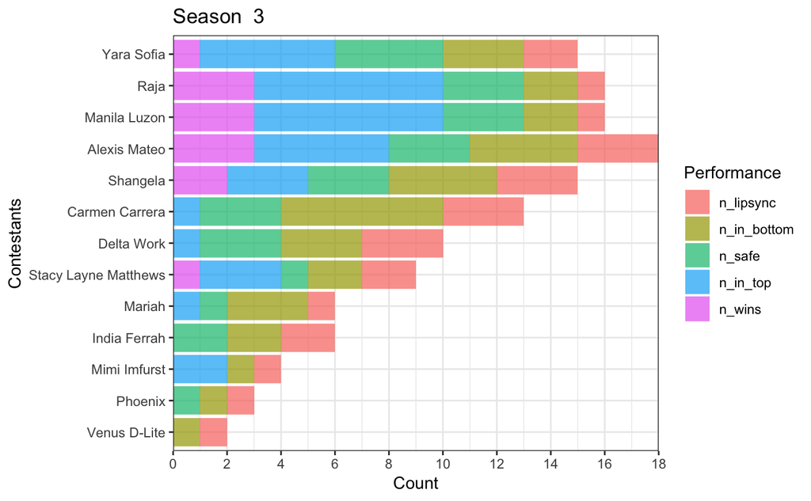

```r
rpdr %>% gather(key = "performance", value = "count", n_lipsync:n_wins) %>%
  filter(season == 3) %>%
  ggplot(aes(x = reorder(contestant, n_appearances), y = count, fill = fct_relevel(performance, "n_lipsync", "n_in_bottom", "n_safe", "n_in_top", "n_wins"))) +
  geom_col(alpha = 0.7) +
  coord_flip() +
  labs(y = "Count", fill  = "Performance", x = "Contestants", title = "Season  3") +
  theme_bw() + scale_y_continuous(breaks = c(0, 2, 4, 6, 8, 10, 12, 14, 16, 18), expand = c(0,0))
```

This graph is great because it highlights a point where any model fit to these data will fail. Manila’s and Raja’s performance was identical, so the best we can accomplish with our current measures is a model that predicts they will have an equally likely chance of winning season 3. In other words, the performance data may not be enough to fit a successful model. That said, we haven’t looked at the mini-challenge data, yet.

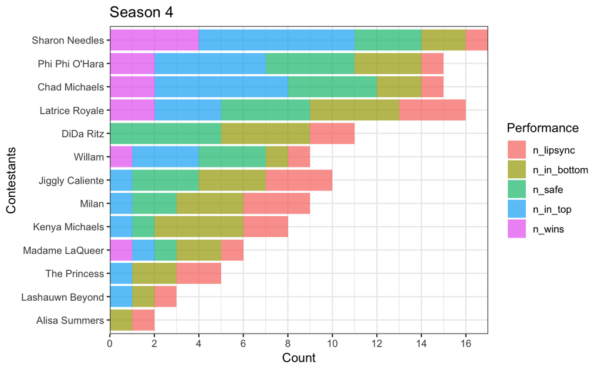

```r
rpdr %>% gather(key = "performance", value = "count", n_lipsync:n_wins) %>%
  filter(season == 4) %>%
  ggplot(aes(x = reorder(contestant, n_appearances), y = count, fill = fct_relevel(performance, "n_lipsync", "n_in_bottom", "n_safe", "n_in_top", "n_wins"))) +
  geom_col(alpha = 0.7) +
  coord_flip() +
  labs(y = "Count", fill  = "Performance", x = "Contestants", title = "Season 4") +
  theme_bw() + scale_y_continuous(breaks = c(0, 2, 4, 6, 8, 10, 12, 14, 16, 18), expand = c(0,0))
```

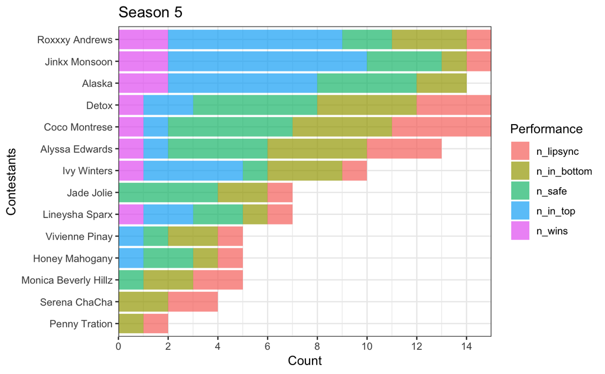

```r
rpdr %>% gather(key = "performance", value = "count", n_lipsync:n_wins) %>%
  filter(season == 5) %>%
  ggplot(aes(x = reorder(contestant, n_appearances), y = count, fill = fct_relevel(performance, "n_lipsync", "n_in_bottom", "n_safe", "n_in_top", "n_wins"))) +
  geom_col(alpha = 0.7) +
  coord_flip() +
  labs(y = "Count", fill  = "Performance", x = "Contestants", title = "Season 5") +
  theme_bw() + scale_y_continuous(breaks = c(0, 2, 4, 6, 8, 10, 12, 14, 16, 18), expand = c(0,0))
```

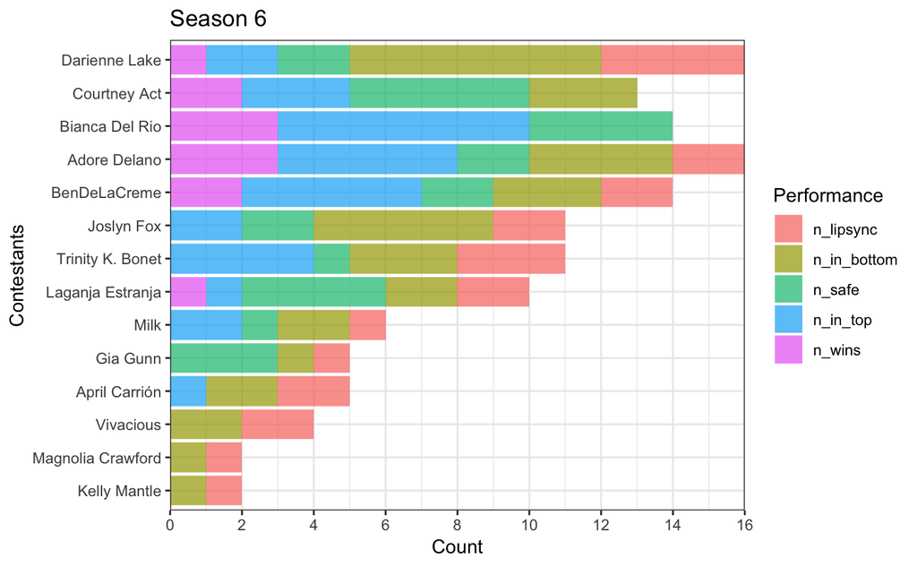

```r
rpdr %>% gather(key = "performance", value = "count", n_lipsync:n_wins) %>%
  filter(season == 6) %>%
  ggplot(aes(x = reorder(contestant, n_appearances), y = count, fill = fct_relevel(performance, "n_lipsync", "n_in_bottom", "n_safe", "n_in_top", "n_wins"))) +
  geom_col(alpha = 0.7) +
  coord_flip() +
  labs(y = "Count", fill  = "Performance", x = "Contestants", title = "Season 6") +
  theme_bw() + scale_y_continuous(breaks = c(0, 2, 4, 6, 8, 10, 12, 14, 16, 18), expand = c(0,0))
```

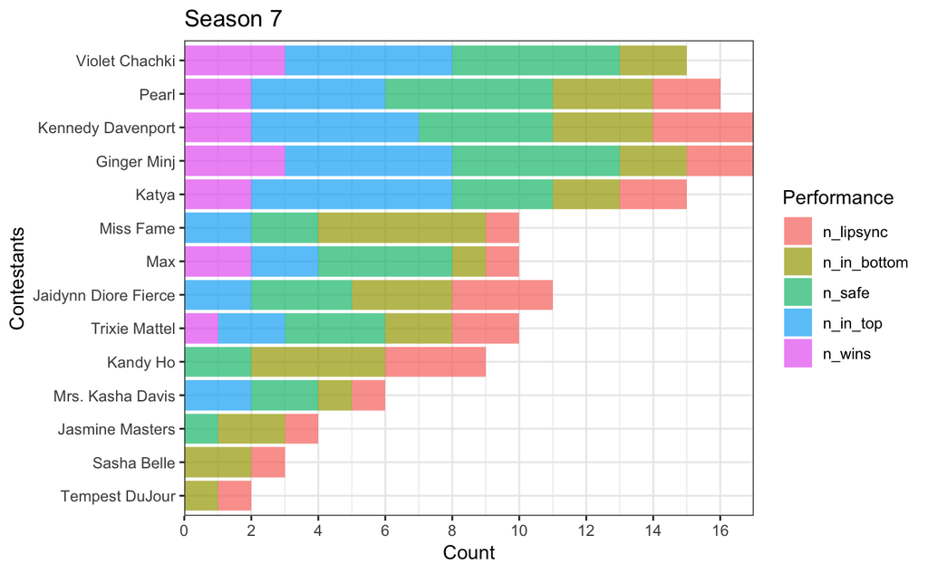

```r
rpdr %>% gather(key = "performance", value = "count", n_lipsync:n_wins) %>%
  filter(season == 7) %>%
  ggplot(aes(x = reorder(contestant, n_appearances), y = count, fill = fct_relevel(performance, "n_lipsync", "n_in_bottom", "n_safe", "n_in_top", "n_wins"))) +
  geom_col(alpha = 0.7) +
  coord_flip() +
  labs(y = "Count", fill  = "Performance", x = "Contestants", title = "Season 7") +
  theme_bw() + scale_y_continuous(breaks = c(0, 2, 4, 6, 8, 10, 12, 14, 16, 18), expand = c(0,0))
```

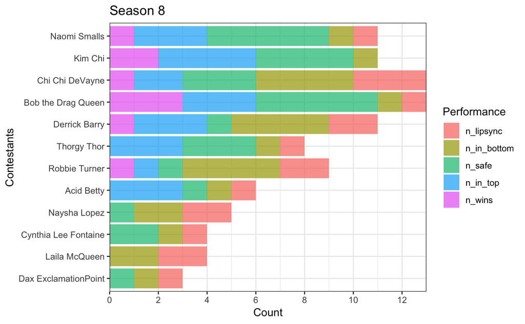

```r
rpdr %>% gather(key = "performance", value = "count", n_lipsync:n_wins) %>%
  filter(season == 8) %>%
  ggplot(aes(x = reorder(contestant, n_appearances), y = count, fill = fct_relevel(performance, "n_lipsync", "n_in_bottom", "n_safe", "n_in_top", "n_wins"))) +
  geom_col(alpha = 0.7) +
  coord_flip() +
  labs(y = "Count", fill  = "Performance", x = "Contestants", title = "Season 8") +
  theme_bw() + scale_y_continuous(breaks = c(0, 2, 4, 6, 8, 10, 12, 14, 16, 18), expand = c(0,0))
```

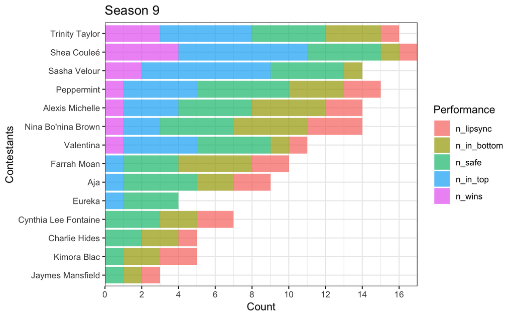

```r
rpdr %>% gather(key = "performance", value = "count", n_lipsync:n_wins) %>%
  filter(season == 9) %>%
  ggplot(aes(x = reorder(contestant, n_appearances), y = count, fill = fct_relevel(performance, "n_lipsync", "n_in_bottom", "n_safe", "n_in_top", "n_wins"))) +
  geom_col(alpha = 0.7) +
  coord_flip() +
  labs(y = "Count", fill  = "Performance", x = "Contestants", title = "Season 9") +
  theme_bw() + scale_y_continuous(breaks = c(0, 2, 4, 6, 8, 10, 12, 14, 16, 18), expand = c(0,0))
```

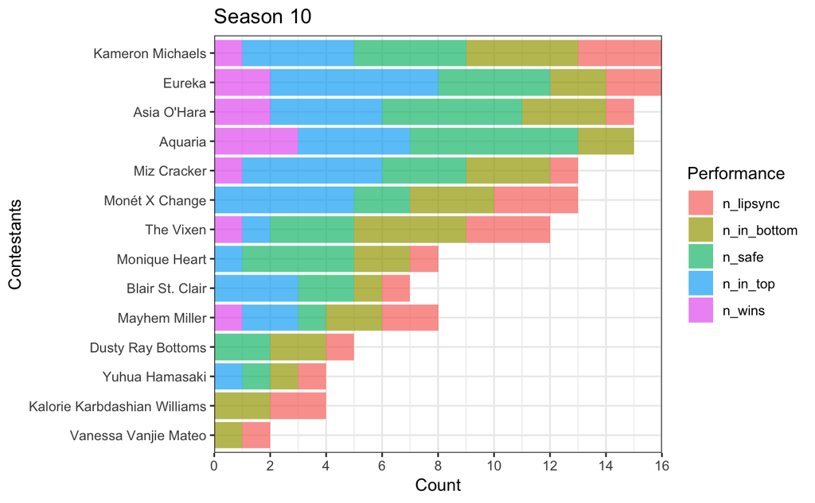

```r
rpdr %>% gather(key = "performance", value = "count", n_lipsync:n_wins) %>%
  filter(season == 10) %>%
  ggplot(aes(x = reorder(contestant, n_appearances), y = count, fill = fct_relevel(performance, "n_lipsync", "n_in_bottom", "n_safe", "n_in_top", "n_wins"))) +
  geom_col(alpha = 0.7) +
  coord_flip() +
  labs(y = "Count", fill  = "Performance", x = "Contestants", title = "Season 10") +
  theme_bw() + scale_y_continuous(breaks = c(0, 2, 4, 6, 8, 10, 12, 14, 16, 18), expand = c(0,0))
```

This suggests to me that we could build a reasonably naive model based on wins and lipsync data alone. So let’s explore that quickly.

```r
rpdr.2 <- rpdr %>%
  group_by(season) %>%
  mutate(most_wins = ifelse(n_wins == max(n_wins), TRUE, FALSE),
  never_lipsynced = ifelse(n_lipsync == 0, TRUE, FALSE))
```

```r
group_by(rpdr.2, season) %>%
  mutate(minval = min(prediction)) %>%
  filter(prediction == minval) %>%
  select(contestant)
```

[output not shown]

| season | contestant |
| --- | --- |
| 1 | BeBe Zahara Benet |
| 1 | Ongina |
| 2 | Tyra Sanchez |
| 3 | Alexis Mateo |
| 3 | Manila Luzon |
| 3 | Raja |
| 4 | Sharon Needles |
| 5 | Alaska |
| 6 | Bianca Del Rio |
| 7 | Violet Chachki |

[output cut: 3 more lines]

```r
ggplot(rpdr, aes(x = n_lipsync, y = n_in_bottom, color = was_winner)) +
  geom_point(position = position_jitter(w = 0.3, h = 0.3), alpha = 0.8) +
  geom_hline(yintercept = 2, linetype = 2) +
  geom_vline(xintercept = 1, linetype = 2) +
  theme_bw()
```

[output not shown]